# Лабораторная работа №7

Презентация

Миличевич Александра

Российский университет дружбы народов, Москва, Россия

15 февраля 2025

## Цель лабораторной работы

Цель лабораторной работы №7 заключается в ознакомлении студентов с алгоритмом Полларда для дискретного логарифмирования. Студенты должны изучить и реализовать алгоритм, который позволяет находить дискретные логарифмы в конечных полях, а также понять его применение в криптографии и теории чисел.

## 1. Функция `modular_inverse(a, n)`

Эта функция вычисляет обратное к `a` по модулю `n`.

**Описание:**

**Вход:**

- `a` (int): Число, для которого ищется обратное.
- `n` (int): Модуль.

**Выход:**

Обратное к `a` по модулю `n`.

**Как работает:**

1. Используется функция `extended_euclidean(a, n)` для получения коэффициентов Безу.
2. Возвращается коэффициент `x` (второй элемент в кортеже), который является обратным к `a` по модулю `n`.
3. Возвращается коэффициент `x` (второй элемент в кортеже), который является обратным к `a` по модулю `n`.

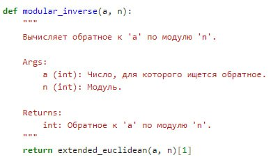

modular inverse

## 2. Функция `pollard_step(x, a, b, params)`

Эта функция реализует один шаг алгоритма Полларда для дискретного логарифмирования.

**Описание:**

**Вход:**

- `x` (int): Текущее значение `x`.
- `a` (int): Текущее значение `a`.
- `b` (int): Текущее значение `b`.
- `params` (tuple): Параметры (G, H, P, Q).

**Выход:**

Кортеж обновленных значений `(x, a, b)`.

**Как работает:**

**Разделение на подмножества:**

Использует `x % 3` для определения подмножества.

**Обновление значений в зависимости от подмножества:**

- Если `x % 3 == 0`: `x` умножается на `G` по модулю `P`, `a` увеличивается на 1 по модулю `Q`.
- Если `x % 3 == 1`: `x` умножается на `H` по модулю `P`, `b` увеличивается на 1 по модулю `Q`.
- Если `x % 3 == 2`: `x` возводится в квадрат по модулю `P`, `a` и `b` умножаются на 2 по модулю `Q`.

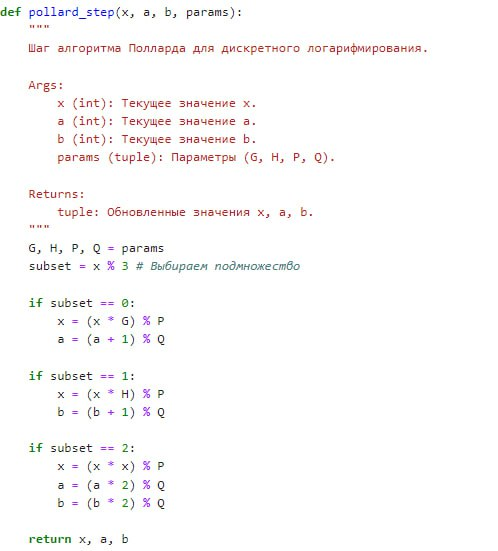

pollard step

## 3. Функция `pollard_rho_discrete_log(generator, value, prime)`

Эта функция реализует алгоритм Полларда для дискретного логарифмирования.

**Описание:**

**Вход:**

- `generator` (int): Генератор группы.
- `value` (int): Значение, для которого ищется дискретный логарифм.
- `prime` (int): Простое число (порядок группы).

**Выход:**

Дискретный логарифм (если найден) или сообщение об ошибке.

**Как работает:**

**Инициализация:**

Устанавливаются начальные значения `Q`, `x`, `a`, `b`, `X`, `A`, `B`.

**Вычисление дискретного логарифма:**

- Вычисляется числитель `a - A` и знаменатель `B - b`.
- Вычисляется обратный элемент знаменателя по модулю `Q` с помощью функции `modular_inverse`.
- Вычисляется дискретный логарифм: `(inverse_denominator * numerator) % Q`.

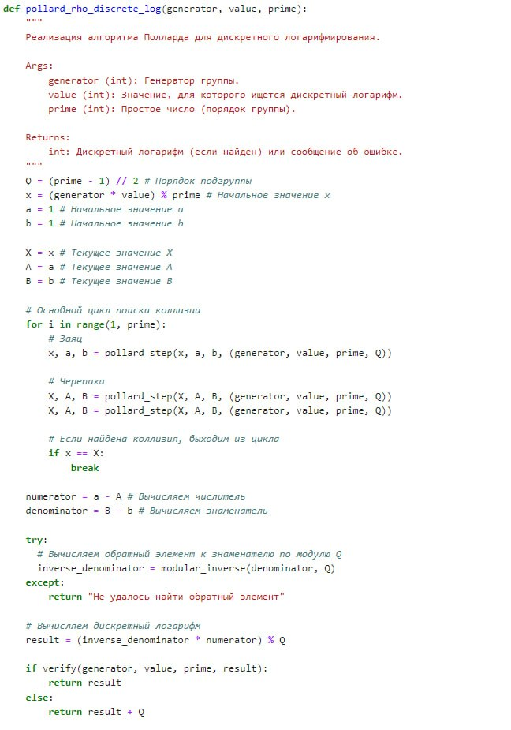

pollard descrete log

## Функция `verify(generator, value, prime, x)`

Эта функция проверяет правильность вычисленного дискретного логарифма.

**Описание:**

**Вход:**

- `generator` (int): Генератор группы.
- `value` (int): Значение, для которого ищется дискретный логарифм.
- `prime` (int): Простое число (порядок группы).
- `x` (int): Вычисленный дискретный логарифм.

**Выход:**

`True`, если логарифм верный, `False` в противном случае.

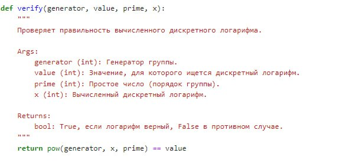

verify

## Вывод

Изучили задачу дискретного логарифмирования.